# Written Assignment 04

AUTHOR  
Maysun Dietrick

## Assignment Goal

The goal of this assignment is to demonstrate your understanding of how the concepts from information theory can be used to build machine learning models for predictive tasks.

### 1 Calculating Entropy

The figure below shows a set of eight Scrabble pieces.

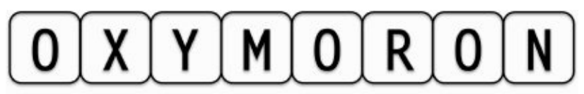

```python
from IPython.display import display
from PIL import Image

display(Image.open('scrabble.png'))
```

#### 1. What is the entropy (in bits) of the letters in this set?

```python
from collections import Counter
from scipy.stats import entropy
import numpy as np

def calculate_letter_entropy(word, letter):
    # Count the frequency of each letter in the word
    letter_counts = Counter(word)

    # Get the total number of letters in the word
    total_letters = len(word)

    # Calculate the probability of the particular letter
    letter_probability = letter_counts[letter] / total_letters

    # Calculate the entropy contribution of the particular letter
    if letter_probability > 0:
        letter_entropy = -letter_probability * np.log2(letter_probability)
    else:
        letter_entropy = 0

    return letter_entropy

word = "OXYMORON"
letter = "O"
print(f"Entropy of the letter '{letter}' in the word '{word}': {calculate_letter_entropy(word, letter):.4f}")

letter = "X"
print(f"Entropy of the letter '{letter}' in the word '{word}': {calculate_letter_entropy(word, letter)}")

letter = "Y"
print(f"Entropy of the letter '{letter}' in the word '{word}': {calculate_letter_entropy(word, letter)}")

letter = "M"
print(f"Entropy of the letter '{letter}' in the word '{word}': {calculate_letter_entropy(word, letter)}")

letter = "R"
print(f"Entropy of the letter '{letter}' in the word '{word}': {calculate_letter_entropy(word, letter)}")

letter = "N"
print(f"Entropy of the letter '{letter}' in the word '{word}': {calculate_letter_entropy(word, letter)}")
```

```
Entropy of the letter 'O' in the word 'OXYMORON': 0.5306
Entropy of the letter 'X' in the word 'OXYMORON': 0.375
Entropy of the letter 'Y' in the word 'OXYMORON': 0.375
Entropy of the letter 'M' in the word 'OXYMORON': 0.375
Entropy of the letter 'R' in the word 'OXYMORON': 0.375
Entropy of the letter 'N' in the word 'OXYMORON': 0.375
```

Entropy of the letter 'O' in the word 'OXYMORON': 0.5306  
Entropy of the letter 'X' in the word 'OXYMORON': 0.375  
Entropy of the letter 'Y' in the word 'OXYMORON': 0.375  
Entropy of the letter 'M' in the word 'OXYMORON': 0.375  
Entropy of the letter 'R' in the word 'OXYMORON': 0.375  
Entropy of the letter 'N' in the word 'OXYMORON': 0.375

#### 2. What would be the reduction in entropy (i.e., the information gain) in bits if we split these letters into two sets, one containing the vowels and the other containing the consonants?

```python
def calculate_entropy(word):
    letter_counts = Counter(word)
    probabilities = np.array(list(letter_counts.values())) / len(word)
    return entropy(probabilities, base=2)

word = "OXYMORON"
original_entropy = calculate_entropy(word)
print(f"Original Entropy: {original_entropy:.4f} bits")
```

```
Original Entropy: 2.4056 bits
```

```python
vowels = "AEIOU"
consonants = "".join([char for char in word if char not in vowels])
vowel_set = "".join([char for char in word if char in vowels])

vowel_entropy = calculate_entropy(vowel_set)
consonant_entropy = calculate_entropy(consonants)

print(f"Vowel Entropy: {vowel_entropy:.4f} bits")
print(f"Consonant Entropy: {consonant_entropy:.4f} bits")
```

```
Vowel Entropy: 0.0000 bits
Consonant Entropy: 2.3219 bits
```

```python
total_entropy_after_split = vowel_entropy + consonant_entropy
print(f"Total Entropy After Split: {total_entropy_after_split:.4f} bits")
```

```
Total Entropy After Split: 2.3219 bits
```

```python
information_gain = original_entropy - total_entropy_after_split
print(f"Information Gain: {information_gain:.4f} bits")
```

```
Information Gain: 0.0837 bits
```

**Information Gain: 0.0837 bits**

#### 3. What is the maximum possible entropy (in bits) for a set of eight Scrabble pieces?

```python
def max_entropy(num_pieces):
    # Each piece has an equal probability
    probabilities = np.full(num_pieces, 1 / num_pieces)

    # Calculate the entropy
    entropy_value = entropy(probabilities, base=2)

    return entropy_value

num_pieces = 8
max_entropy_value = max_entropy(num_pieces)
print(f"Maximum possible entropy for a set of {num_pieces} Scrabble pieces: {max_entropy_value:.4f} bits")
```

```
Maximum possible entropy for a set of 8 Scrabble pieces: 3.0000 bits
```

**Maximum possible entropy for a set of 8 Scrabble pieces: 3.0000 bits**

#### 4. In general, which is preferable when you are playing Scrabble: a set of letters with high entropy, or a set of letters with low entropy?

**In general, a set of letters with high entropy is preferable because you have a greater variety of letters for forming a word. Even better would also be having a high entropy of both vowels and consonants. If you have low entropy of one, it means you either have two many vowels or too many consonants, which would also increase the difficulty of forming a word.**

### 2 Decision Tree Construction

A convicted criminal who reoffends after release is known as a recidivist. The Table below lists a dataset that describes prisoners released on parole, and whether they reoffended within two years of release.

```python
import pandas as pd

file_name = "Recidivist.csv"
df = pd.read_csv(file_name)
df
```

|  | Good Behavior | Age Below 30 | Drug Dependent | Recidivist |
| --- | --- | --- | --- | --- |
| 0 | False | True | False | True |
| 1 | False | False | False | False |
| 2 | False | True | False | True |
| 3 | True | False | False | False |
| 4 | True | False | True | True |
| 5 | True | False | False | False |

This dataset lists six instances where prisoners were granted parole. Each of these instances are described in terms of three binary descriptive features (Good Behavior, Age Below 30, Drug Dependent) and a binary target feature, Recidivist. The Good Behavior feature has a value of true if the prisoner had not committed any infringements during incarceration, the Age Below 30 has a value of true if the prisoner was under 30 years of age when granted parole, and the Drug Dependent feature is true if the prisoner had a drug addiction at the time of parole. The target feature, Recidivist, has a true value if the prisoner was arrested within two years of being released; otherwise it has a value of false.

#### 1. Using this dataset, construct the decision tree that would be generated by the ID3 algorithm, using entropy-based information gain.

```
Accuracy: 100.00%
Confusion Matrix:
[[1 0]
 [0 1]]

Classification Report:
              precision    recall  f1-score   support

       False       1.00      1.00      1.00         1
        True       1.00      1.00      1.00         1

    accuracy                           1.00         2
   macro avg       1.00      1.00      1.00         2
weighted avg       1.00      1.00      1.00         2
```

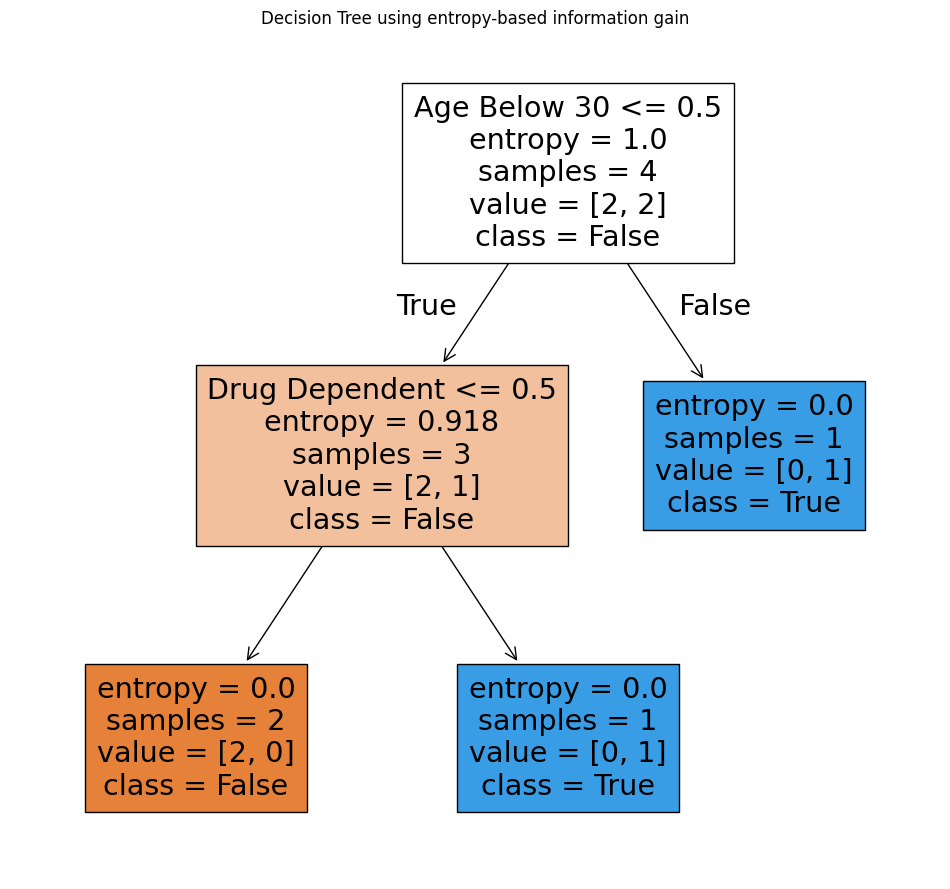

```python
# Import necessary libraries

from sklearn.datasets import load_iris
from sklearn.model_selection import train_test_split
from sklearn.tree import DecisionTreeClassifier
from sklearn.metrics import accuracy_score, confusion_matrix, classification_report
import matplotlib.pyplot as plt
from sklearn.tree import plot_tree


X = df.drop('Recidivist', axis=1).values # Features
y = df['Recidivist'].values # Target labels

# Step 2: Split the dataset into training and test sets (80% train, 20% test)
X_train, X_test, y_train, y_test = train_test_split(
X, y, test_size=0.2, random_state=42)
# Step 3: Initialize and train the Decision Tree classifier
clf = DecisionTreeClassifier(criterion='entropy',random_state=42)
clf.fit(X_train, y_train)
# Step 4: Make predictions on the test set
y_pred = clf.predict(X_test)
# Step 5: Evaluate the model
accuracy = accuracy_score(y_test, y_pred)
conf_matrix = confusion_matrix(y_test, y_pred)
# Print evaluation results
print(f'Accuracy: {accuracy * 100:.2f}%')
print('Confusion Matrix:')
print(conf_matrix)
print('\nClassification Report:')
print(classification_report(y_test, y_pred, target_names=['False', 'True']))
# Step 6: Visualize the decision tree
plt.figure(figsize=(12, 11))
plot_tree(clf, feature_names=['Good Behavior', 'Age Below 30', 'Drug Dependent'],
class_names=['False', 'True'], filled=True)
plt.title("Decision Tree using entropy-based information gain")
plt.show()
```

#### 2. What prediction will the decision tree generated in part (a) of this question return for the following query?

Good Behavior = false, Age Below 30 = false, Drug Dependent = true

```python
query = np.array([[0, 0, 1]])

prediction = clf.predict(query)

print(prediction)
```

```
[ True]
```

**Prediction will return True**

#### 3. What prediction will the decision tree generated in part (a) of this question return for the following query?

Good Behavior = true, Age Below 30 = true, Drug Dependent = false

```python
query = np.array([[1, 1, 0]])

prediction = clf.predict(query)

print(prediction)
```

```
[ True]
```

**Prediction will return True**

### 3 Information Gain

The Table below lists a sample of data from a census.

```python
file_name = "Annual Income.csv"
df1 = pd.read_csv(file_name)

df1
```

|  | Age | Education | Marital Status | Occupation | Annual Income |
| --- | --- | --- | --- | --- | --- |
| 0 | 39 | bachelors | never married | transport | 25K-50K |
| 1 | 50 | bachelors | married | professional | 25K-50K |
| 2 | 18 | high school | never married | agriculture | below 25K |
| 3 | 28 | bachelors | married | professional | 25K-50K |
| 4 | 37 | high school | married | agriculture | 25K-50K |
| 5 | 24 | high school | never married | armed forces | below 25K |
| 6 | 52 | high school | divorced | transport | 25K-50K |
| 7 | 40 | doctorate | married | professional | over 50K |

There are four descriptive features and one target feature in this dataset:

Age, a continuous feature listing the age of the individual.

Education, a categorical feature listing the highest education award achieved by the individual (high school, bachelors, doctorate).

Marital Status (never married, married, divorced).

Occupation (transport = works in the transportation industry; professional = doctors, lawyers, etc.; agriculture = works in the agricultural industry; armed forces = is a member of the armed forces).

Annual Income, the target feature with 3 levels (<25K, 25K-50K, >50K).

#### 1. Calculate the entropy for this dataset.

```python
target_feature_mapping = {'below 25K': 1, '25K-50K': 2, 'over 50K': 3}
df1['Annual Income'] = df1['Annual Income'].map(target_feature_mapping)

education_mapping = {'high school': 1, 'bachelors': 2, 'doctorate': 3}
df1['Education'] = df1['Education'].map(education_mapping)

marital_status_mapping = {'never married': 1, 'married': 2, 'divorced': 3}
df1['Marital Status'] = df1['Marital Status'].map(marital_status_mapping)

occupation_mapping = {'transport': 1, 'professional': 2, 'agriculture': 3, 'armed forces': 4}
df1['Occupation'] = df1['Occupation'].map(occupation_mapping)

df1.to_csv('updated_annual_income.csv', index=False)
```

```python
annual_income = np.array(df1['Annual Income'])

income_hist = np.bincount(y)

income_ps = income_hist / len(y)

income_entropy = -np.sum([p * np.log2(p) for p in income_ps if p > 0])

print(f'Entropy: {income_entropy:.4f} bits')
```

```
Entropy: 1.0000 bits
```

#### 2. Calculate the Gini index for this dataset.

```python
gini = 1 - np.sum(income_ps ** 2)
print(f'Gini Index: {gini:.4f}')
```

```
Gini Index: 0.5000
```

#### 3. When building a decision tree, the easiest way to handle a continuous feature is to define a threshold around which splits will be made. What would be the optimal threshold to split the continuous Age feature (use information gain based or entropy as the feature selection measure)?

```python
df1 = df1.sort_values(by='Age')
age_values = df1['Age'].values
target_values = df1['Annual Income'].values

def calculate_entropy(y):
    hist = np.bincount(y)
    ps = hist / len(y)
    return -np.sum([p * np.log2(p) for p in ps if p > 0])

def calculate_information_gain(df, threshold, target_column='Annual Income'):
    left_split = df1[df1['Age'] <= threshold][target_column]
    right_split = df1[df1['Age'] > threshold][target_column]

    parent_entropy = calculate_entropy(df1[target_column])
    n = len(df1)
    n_left, n_right = len(left_split), len(right_split)
    e_left, e_right = calculate_entropy(left_split), calculate_entropy(right_split)

    child_entropy = (n_left / n) * e_left + (n_right / n) * e_right
    information_gain = parent_entropy - child_entropy
    return information_gain

# Determine the best threshold
best_threshold = None
best_information_gain = -1

for i in range(1, len(age_values)):
    threshold = (age_values[i - 1] + age_values[i]) / 2
    information_gain = calculate_information_gain(df1, threshold)

    if information_gain > best_information_gain:
        best_information_gain = information_gain
        best_threshold = threshold

print(f'Best Threshold: {best_threshold}')
print(f'Best Information Gain: {best_information_gain:.4f}')
```

```
Best Threshold: 26.0
Best Information Gain: 0.8113
```

Best Threshold: 26.0  
Best Information Gain: 0.8113

#### 4. Calculate information gain (based on entropy) for the Education, Marital Status, and Occupation features.

```python
def calculate_entropy(y):
    hist = np.bincount(y)
    ps = hist / len(y)
    return -np.sum([p * np.log2(p) for p in ps if p > 0])

# Calculate the parent entropy
parent_entropy = calculate_entropy(df1['Annual Income'].values)

# Define the function to calculate information gain
def calculate_information_gain(df, feature, target='Annual Income'):
    values = df[feature].unique()
    feature_entropy = 0

    for value in values:
        subset = df[df[feature] == value][target]
        subset_entropy = calculate_entropy(subset)
        feature_entropy += (len(subset) / len(df)) * subset_entropy

    information_gain = parent_entropy - feature_entropy
    return information_gain

ig_education = calculate_information_gain(df1, 'Education')
print(f'Information Gain for Education: {ig_education:.4f}')

ig_marital_status = calculate_information_gain(df1, 'Marital Status')
print(f'Information Gain for Marital Status: {ig_marital_status:.4f}')

ig_occupation = calculate_information_gain(df1, 'Occupation')
print(f'Information Gain for Occupation: {ig_occupation:.4f}')
```

```
Information Gain for Education: 0.7988
Information Gain for Marital Status: 0.5488
Information Gain for Occupation: 0.7044
```

Information Gain for Education: 0.7988  
Information Gain for Marital Status: 0.5488  
Information Gain for Occupation: 0.7044

#### 5. Calculate the information gain ratio (based on entropy) for Education, Marital Status, and Occupation features.

```python
def calculate_instrinsic_value(df, feature):
    values = df[feature].unique()
    instrinsic_value = 0

    for value in values:
        subset = df[df[feature] == value]
        prob = len(subset) / len(df)
        instrinsic_value -= prob * np.log2(prob)

    return instrinsic_value

def calculate_information_gain_ratio(df, feature):
    information_gain = calculate_information_gain(df, feature)
    weighted_value = calculate_instrinsic_value(df, feature)
    if weighted_value == 0:
        return 0
    return information_gain / weighted_value

igr_education = calculate_information_gain_ratio(df1, 'Education')
igr_marital_status = calculate_information_gain_ratio(df1, 'Marital Status')
igr_occupation = calculate_information_gain_ratio(df1, 'Occupation')

print(f'Information Gain Ratio for Education: {igr_education:.4f}')
print(f'Information Gain Ratio for Marital Status: {igr_marital_status:.4f}')
print(f'Information Gain Ratio for Occupation: {igr_occupation:.4f}')
```

```
Information Gain Ratio for Education: 0.5683
Information Gain Ratio for Marital Status: 0.3904
Information Gain Ratio for Occupation: 0.3697
```

Information Gain Ratio for Education: 0.5683  
Information Gain Ratio for Marital Status: 0.3904  
Information Gain Ratio for Occupation: 0.3697

#### 6. Calculate information gain using the Gini index for the Education, Marital Status, and Occupation features.

```python
# Function to calculate Gini index
def calculate_gini(y):
    hist = np.bincount(y)
    ps = hist / len(y)
    return 1 - np.sum(ps ** 2)

# Calculate the parent Gini index
income_gini = calculate_gini(df1['Annual Income'].values)

# Function to calculate information gain using Gini index
def calculate_information_gain_gini(df, feature, target='Annual Income'):
    values = df[feature].unique()
    feature_gini = 0

    for value in values:
        subset = df[df[feature] == value][target]
        subset_gini = calculate_gini(subset)
        feature_gini += (len(subset) / len(df)) * subset_gini

    information_gain = income_gini - feature_gini
    return information_gain

# Calculate information gain for each feature using Gini index
ig_education_gini = calculate_information_gain_gini(df1, 'Education')
ig_marital_status_gini = calculate_information_gain_gini(df1, 'Marital Status')
ig_occupation_gini = calculate_information_gain_gini(df1, 'Occupation')

print(f'Information Gain (Gini) for Education: {ig_education_gini:.4f}')
print(f'Information Gain (Gini) for Marital Status: {ig_marital_status_gini:.4f}')
print(f'Information Gain (Gini) for Occupation: {ig_occupation_gini:.4f}')
```

```
Information Gain (Gini) for Education: 0.2812
Information Gain (Gini) for Marital Status: 0.1771
Information Gain (Gini) for Occupation: 0.2396
```

Information Gain (Gini) for Education: 0.2812  
Information Gain (Gini) for Marital Status: 0.1771  
Information Gain (Gini) for Occupation: 0.2396

### Decision Tree Error Pruning

Shown in the figure below shows a decision tree for predicting heart disease. The descriptive features in this domain describe whether the patient suffers from chest pain (Chest Pain) and blood pressure (Blood Pressure). The binary target feature is Heart Disease. The table below the diagram lists a pruning set from this domain.

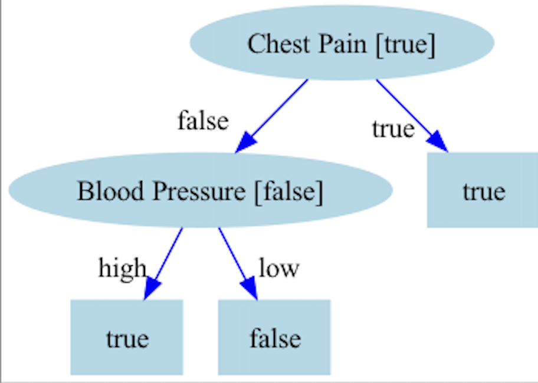

```python
display(Image.open('heart.png'))
```

```python
file_name = "Heart Disease.csv"
df2 = pd.read_csv(file_name)
df2
```

|  | Chest Pain | Blood Pressure | Heart Disease |
| --- | --- | --- | --- |
| 0 | False | high | True |
| 1 | True | low | True |
| 2 | False | low | False |
| 3 | True | high | True |
| 4 | False | high | True |

#### Using the pruning set, apply reduced error pruning to the decision tree. Assume that the algorithm is applied in a bottom-up, left-to-right fashion. For each iteration of the algorithm, indicate the subtrees considered as pruning candidates, explain why the algorithm chooses to prune or leave these subtrees in the tree, and illustrate the tree that results from each iteration.

```python
blood_pressure_mapping = {'low': 0, 'high': 1}
df2['Blood Pressure'] = df2['Blood Pressure'].map(blood_pressure_mapping)

df2.to_csv('updated_heart_disease.csv', index=False)
```

**The first thing that needs to be done is to get the accuracy of the initial decision tree before anything is pruned.**

```
Accuracy: 50.00%
Confusion Matrix:
[[0 0]
 [1 1]]

Classification Report:
              precision    recall  f1-score   support

       False       0.00      1.00      0.00         0
        True       1.00      0.50      0.67         2

    accuracy                           0.50         2
   macro avg       0.50      0.75      0.33         2
weighted avg       1.00      0.50      0.67         2
```

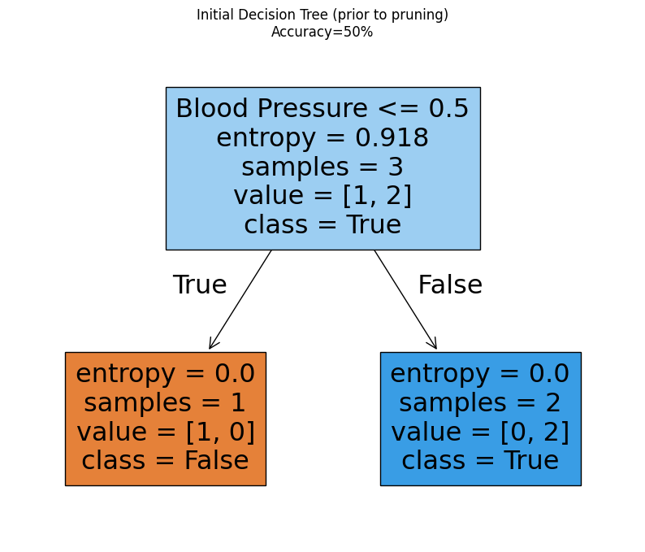

```python
from sklearn.metrics import classification_report


# Step 1: Load the dataset (Iris dataset for demonstration)
X = df2.drop('Heart Disease', axis=1).values # Features
y = df2['Heart Disease'].values # Target labels

# Step 2: Split the dataset into training and test sets (80% train, 20% test)
X_train, X_test, y_train, y_test = train_test_split(
X, y, test_size=0.3, random_state=42)
# Step 3: Initialize and train the Decision Tree classifier
clf = DecisionTreeClassifier(criterion='entropy', random_state=42)
clf.fit(X_train, y_train)
# Step 4: Make predictions on the test set
y_pred = clf.predict(X_test)
# Step 5: Evaluate the model
accuracy = accuracy_score(y_test, y_pred)
conf_matrix = confusion_matrix(y_test, y_pred)
# Print evaluation results
print(f'Accuracy: {accuracy * 100:.2f}%')
print('Confusion Matrix:')
print(conf_matrix)
print('\nClassification Report:')
print(classification_report(y_test, y_pred, target_names=['False', 'True'], zero_division=1))
# Step 6: Visualize the decision tree
plt.figure(figsize=(10,8))
plot_tree(clf, feature_names=['Chest Pain', 'Blood Pressure'],
class_names=['False', 'True'], filled=True)
plt.title("Initial Decision Tree (prior to pruning)\nAccuracy=50%")
plt.show()
```

**The current tree has an accuracy of 50%. Next, starting with the bottom left internal node, "Blood Pressure," we will make "Blood Pressure" a leaf node and see if accuracy improves or stays the same.**

```
Accuracy: 50.00%
Confusion Matrix:
[[0 0]
 [1 1]]

Classification Report:
              precision    recall  f1-score   support

       False       0.00      1.00      0.00         0
        True       1.00      0.50      0.67         2

    accuracy                           0.50         2
   macro avg       0.50      0.75      0.33         2
weighted avg       1.00      0.50      0.67         2
```

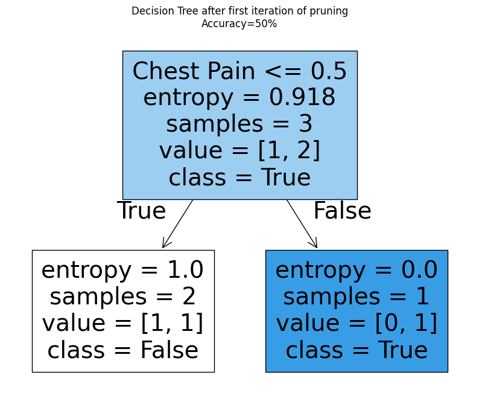

```python
# Step 1: Load the dataset (Iris dataset for demonstration)
X = df2.drop(['Heart Disease', 'Blood Pressure'], axis=1).values # Features
y = df2['Heart Disease'].values # Target labels

# Step 2: Split the dataset into training and test sets (80% train, 20% test)
X_train, X_test, y_train, y_test = train_test_split(
X, y, test_size=0.3, random_state=42)
# Step 3: Initialize and train the Decision Tree classifier
clf = DecisionTreeClassifier(criterion='entropy', max_depth=None, min_samples_split=2, max_features=2, random_state=42)
clf.fit(X_train, y_train)
# Step 4: Make predictions on the test set
y_pred = clf.predict(X_test)
# Step 5: Evaluate the model
accuracy = accuracy_score(y_test, y_pred)
conf_matrix = confusion_matrix(y_test, y_pred)
# Print evaluation results
print(f'Accuracy: {accuracy * 100:.2f}%')
print('Confusion Matrix:')
print(conf_matrix)
print('\nClassification Report:')
print(classification_report(y_test, y_pred, target_names=['False', 'True'], zero_division=1))
# Step 6: Visualize the decision tree
plt.figure(figsize=(10,8))
plot_tree(clf, feature_names=['Chest Pain'],
class_names=['False', 'True'], filled=True)
plt.title("Decision Tree after first iteration of pruning\nAccuracy=50%")
plt.show()
```

**After removing "Blood Pressure", the accuracy of the decision tree did not change and is still at 50%. Since this is the same accuracy as the prior tree, it is safe to go ahead and remove "Blood Pressure." We now are left with just our root node, so there are no more iterations to be made for pruning.**

### 5 Random Forest

Exercise - how regularly do they exercise

Smoker - do they smoke

Obese - are they overweight

Family - did any of their parents or siblings suffer from heart disease

```python
file_name = "Risk for Heart Disease.csv"
df3 = pd.read_csv(file_name)
df3
```

|  | Exercise | Smoker | Obese | Family | Risk |
| --- | --- | --- | --- | --- | --- |
| 0 | daily | False | False | yes | low |
| 1 | weekly | True | False | yes | high |
| 2 | daily | False | False | no | low |
| 3 | rarely | True | True | yes | high |
| 4 | rarely | True | True | no | high |

As part of the study researchers have decided to create a predictive model to screen participants based on their risk of heart disease. You have been asked to implement this screening model using a random forest. Table below list three bootstrap samples that have been generated from the above dataset.

Bootstrap Sample A

```python
file_name_a = "Heart Study Bootstrap Sample A.csv"
boostrap_a = pd.read_csv(file_name_a)
boostrap_a
```

|  | Exercise | Family | Risk |
| --- | --- | --- | --- |
| 0 | daily | yes | low |
| 1 | weekly | yes | high |
| 2 | weekly | yes | high |
| 3 | rarely | yes | high |
| 4 | rarely | no | high |

Bootstrap Sample B

```python
file_name_b = "Heart Study Bootstrap Sample B.csv"
boostrap_b = pd.read_csv(file_name_b)
boostrap_b
```

|  | Smoker | Obese | Risk |
| --- | --- | --- | --- |
| 0 | False | False | low |
| 1 | True | False | high |
| 2 | True | False | high |
| 3 | True | True | high |
| 4 | True | True | high |

Bootstrap Sample C

```python
file_name_c = "Heart Study Bootstrap Sample C.csv"
boostrap_c = pd.read_csv(file_name_c)
boostrap_c
```

|  | Obese | Family | Risk |
| --- | --- | --- | --- |
| 0 | False | yes | low |
| 1 | False | yes | low |
| 2 | False | yes | high |
| 3 | True | yes | high |
| 4 | True | no | high |

#### 1. Using these bootstrap samples create the decision trees that will be in the random forest model (use entropy based information gain as the feature selection criterion).

```python
exercise_mapping = {'rarely': 0, 'weekly': 1, 'daily': 2}
df3['Exercise'] = df3['Exercise'].map(exercise_mapping)

family_mapping = {'no': 0, 'yes': 1}
df3['Family'] = df3['Family'].map(family_mapping)

risk_mapping = {'low': 0, 'high': 1}
df3['Risk'] = df3['Risk'].map(risk_mapping)
```

```python
bootstrap_sample_a = pd.read_csv(file_name_a)
bootstrap_sample_b = pd.read_csv(file_name_b)
bootstrap_sample_c = pd.read_csv(file_name_c)

bootstrap_sample_a['Exercise'] = bootstrap_sample_a['Exercise'].map(exercise_mapping)
bootstrap_sample_a['Family'] = bootstrap_sample_a['Family'].map(family_mapping)
bootstrap_sample_a['Risk'] = bootstrap_sample_a['Risk'].map(risk_mapping)

bootstrap_sample_b['Risk'] = bootstrap_sample_b['Risk'].map(risk_mapping)

bootstrap_sample_c['Family'] = bootstrap_sample_c['Family'].map(family_mapping)
bootstrap_sample_c['Risk'] = bootstrap_sample_c['Risk'].map(risk_mapping)
```

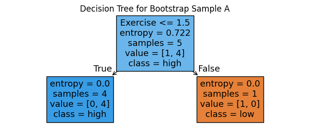

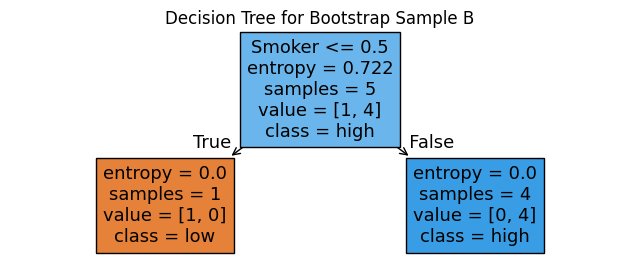

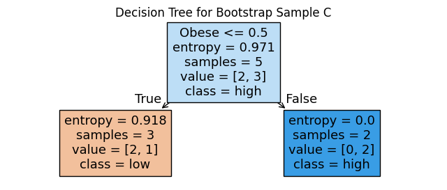

```python
from scipy.stats import mode
headers_a = bootstrap_sample_a.drop('Risk', axis=1).columns
headers_b = bootstrap_sample_b.drop('Risk', axis=1).columns
headers_c = bootstrap_sample_c.drop('Risk', axis=1).columns

X_bootstrap_a = bootstrap_sample_a.drop('Risk', axis=1).values
y_bootstrap_a = bootstrap_sample_a['Risk']

X_bootstrap_b = bootstrap_sample_b.drop('Risk', axis=1).values
y_bootstrap_b = bootstrap_sample_b['Risk']

X_bootstrap_c = bootstrap_sample_c.drop('Risk', axis=1).values
y_bootstrap_c = bootstrap_sample_c['Risk']
# Your custom bootstrap samples (as lists of indices)
bootstrap_samples = [(X_bootstrap_a, y_bootstrap_a), (X_bootstrap_b, y_bootstrap_b), (X_bootstrap_c, y_bootstrap_c)] # replace with your actual bootstrap sample indices
bootstrap_headers = [headers_a, headers_b, headers_c]

# Train each tree on its respective bootstrap sample
trees = []
for X, y in bootstrap_samples:
    tree = DecisionTreeClassifier(criterion='entropy', max_leaf_nodes=None)
    tree.fit(X, y)
    trees.append(tree)

tree_n = 0
for tree in trees:
    headers = bootstrap_headers[trees.index(tree)]
    plt.figure(figsize=(8, 3))
    plot_tree(tree, feature_names=headers, class_names=['low', 'high'], filled=True)
    plt.title(f'Decision Tree for Bootstrap Sample {chr(65 + tree_n)}')
    plt.show()
    tree_n += 1
```

#### 2. Assuming the random forest model you have created uses majority voting, what prediction will it return for the following query:

Exercise=rarely, Smoker=false, Obese=true, Family=yes

**Assuming that the model uses majority voting:**

**Sample A will return 'high'**  
**Sample B will return 'low'**  
**Sample C will return 'high'**

**Resulting in a majority vote and prediction return of 'high'**